# Stratigaphic diagrams

PalaeOpen Training School — Sofia, 18 June 2026

Author

Xavier Benito

Modified

June 18, 2026

## Learning Objectives

1. Obtain sample information for the selected sites and datasets
2. Structure sample data for stratigraphic plotting and customize diagrams
3. Build reproducible workflows using Quarto

## Online resources

1. [Code repository for the workshop](https://github.com/PalaeOpen/workshop-neotoma2-stratplots-trainingschool)
2. [Neotoma Palaeoecology Database Manual](https://open.neotomadb.org/manual/)
3. [neotoma2 GitHub Repository](https://github.com/neotomadb/neotoma2) including previous Neotoma workshop repositories
4. [PalaeOpen R Zulip channel](https://palaeopen.zulipchat.com/#narrow/channel/540741-it_r)
5. [Neotoma Slack channel](https://neotomadb.slack.com/join/shared_invite/zt-cvsv53ep-wjGeCTkq7IhP6eUNA9NxYQ#/shared-invite/email)

## Install and load the necessary packages

This workflow relies on different R libraries, including tidyverse, geojsonsf and leaflet, to handle geographic data and interactive mapping. To streamline the setup, we utilize the pacman management tool. If any required package is missing from your local environment, pacman will automatically download and install it before loading.

```r
# Clean workspace first
rm(list = ls())
#install.packages("pacman") #install the package to load the necessary packages
pacman::p_load(neotoma2, tidyverse, tidypaleo, ggplot2, sf, geojsonsf, leaflet, raster, egg, openxlsx, cowplot, patchwork)
```

# Stratigraphic plot

There exists several packages to perform stratigraphic diagrams of your data. The data needs to be on long or wide format as a function of the package used:

| Package | Data structure | function |
| --- | --- | --- |
| *ggplot2* | long format | `ggplot()` |
| *tidypaleo* | long format | `ggplot()` |
| *analogue* | wide format | `Stratiplot()` |
| *rioja* | wide format | `strat.plot()` |
| *riojaPlot* | wide format | `riojaPlot()` |

In this tutorial we will use two different packages: [`tidypaleo`](https://paleolimbot.github.io/tidypaleo/index.html) and [`riojaPlot`](https://nsj3.github.io/riojaPlot_gallery/riojaPlot_Gallery.html#1)

`tidypaleo` can be installed directly from CRAN (`install.packages("tidypaleo)`) and `riojaPlot` is not yet on CRAN. To install it, you can run:

```r
# remotes::install_github("nsj3/riojaPlot", built_vignettes=TRUE, dependencies=TRUE)
# # or
# install.packages("riojaPlot", repos="https://nsj3.r-universe.dev")

# load the library
library(riojaPlot)
```

As we did in the [intro to neotoma2 workshop](https://github.com/PalaeOpen/workshop-neotoma2-trainingschool), we will use the site **Prášilské jezero**.

We first obtain the site metadata including the site’s datasets. Then we filter for **pollen** and **diatoms** datasets.

```r
pra_site <- get_datasets(get_sites(sitename = "Prášilské jezero"), all_data = TRUE) %>%
  neotoma2::filter(datasettype %in% c("pollen","diatom"))
```

Now we extract the records and the samples:

```r
pra_records <- pra_site %>% get_downloads()
datasets(pra_records)
```

```
 datasetid                 database datasettype age_range_old age_range_young
     47520 European Pollen Database      pollen         11954             -58
     55585 European Pollen Database      diatom         11426             -60
 age_units recdatecreated notes
      <NA>           <NA>  <NA>
      <NA>           <NA>  <NA>
```

```r
pra_samp <- pra_records %>% samples()
```

We are interested in creating an stratigraphic diagram with the aquatic and terrestrial datasets of the site. We are going to use two packages.

# Option 1: `tidypaleo`

This package is basically built in `ggplot2` so we need a long-format dataset

## Diatoms

```r
pra_samp_diat <- samples(pra_records) %>%
  dplyr::filter(ecologicalgroup=="DIAT") %>%
  dplyr::filter(taxongroup == "Diatoms")
```

Calculate diatom proportions:

```r
pra_diat_perc <- pra_samp_diat %>%
  dplyr::group_by(depth, age) %>%
  dplyr::mutate(diatcount = sum(value, na.rm = TRUE)) %>%
  dplyr::group_by(variablename) %>%
  dplyr::mutate(relative_abundance_percent = value / diatcount) %>%
  dplyr::arrange(desc(age))
```

Prepare the dataset and plot

```r
diatoms_long <- pra_diat_perc %>%
  dplyr::select(depth, age, variablename, relative_abundance_percent) %>% #select the variables of interest from the sample object
  dplyr::mutate(relative_abundance_percent = as.numeric(relative_abundance_percent)) %>%
  rename(taxa=variablename) %>% #rename column variablename to taxa
  mutate(taxa = factor(taxa))

levels(diatoms_long$taxa) #check which diatom taxa we have
```

```
  [1] "Achnanthidium cf. A. minutissimum"
  [2] "Achnanthidium linearioide"
  [3] "Achnanthidium minutissimum s.l."
  [4] "Achnanthidium spp."
  [5] "Adlafia bryophila"
  [6] "Adlafia spp."
  [7] "Aulacoseira aff. tenella"
  [8] "Aulacoseira alpigena"
  [9] "Aulacoseira ambigua"
 [10] "Aulacoseira cf. A. valida"
 [11] "Aulacoseira cf. alpigena"
 [12] "Aulacoseira lacustris"
 [13] "Aulacoseira laevissima"
 [14] "Aulacoseira lirata"
 [15] "Aulacoseira nivalis"
```

[output cut: 197 more lines]

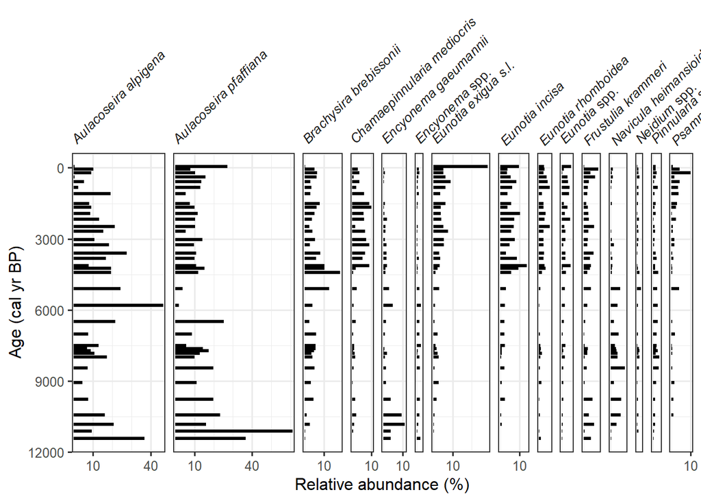

```r
# Here we select the top 15 most abundant diatom taxa
site_plot_diat <- taxa(pra_records) %>%
  dplyr::filter(taxongroup == "Diatoms") %>%
  dplyr::arrange(desc(samples)) %>%
  head(n = 15)

theme_set(theme_bw(base_size=12))
diat_plot <- diatoms_long %>%
  filter(taxa %in% site_plot_diat$variablename) %>%
  ggplot(., aes(x = relative_abundance_percent*100, y = age)) +
  geom_col_segsh(linewidth = 1.2) +
  scale_y_reverse() +
  facet_abundanceh(vars(taxa)) +
  labs(y = "Age (cal yr BP)")
diat_plot
```

Have a look a the diatom plot. You can change plotting parameters adjusting arguments in `geom_col_segsh`. Also, you can add or remove certain taxa:

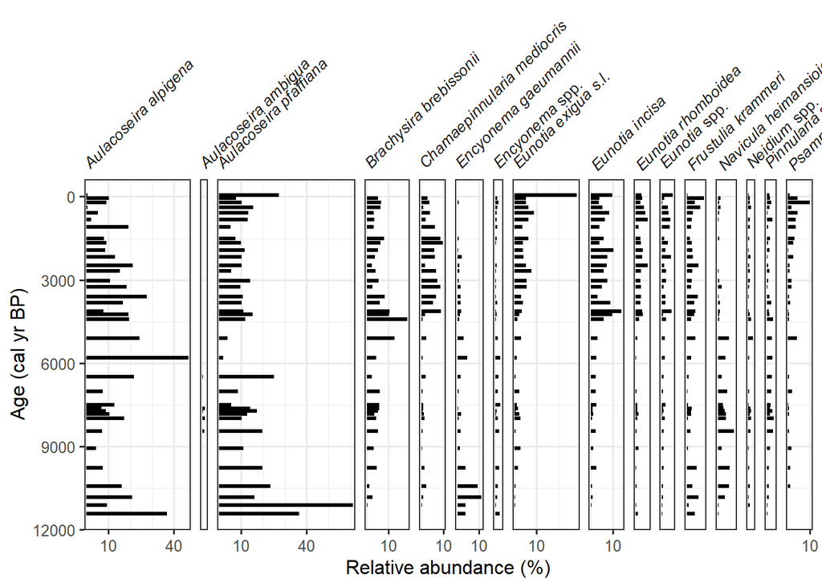

```r
site_plot_diat_aul <- taxa(pra_records) %>%
  dplyr::filter(taxongroup == "Diatoms") %>%
  dplyr::filter(variablename == "Aulacoseira ambigua") %>%
  bind_rows(site_plot_diat)

# Re-do the diagram
diat_plot <- diatoms_long %>%
  filter(taxa %in% site_plot_diat_aul$variablename) %>%
  ggplot(., aes(x = relative_abundance_percent*100, y = age)) +
  geom_col_segsh(linewidth = 1.2) +
  scale_y_reverse() +
  facet_abundanceh(vars(taxa)) +
  labs(y = "Age (cal yr BP)")
diat_plot
```

It is a common practice to find stratigraphic significant zones in the diatom dataset at the right of the abundance plots, and identify them using **cluster** analysis. `tidypaleo` uses the `rioja` package to the CONISS (constrained cluster analysis). The number of statistically significant zones is calculated by default based on a broken stick simulation.

```r
diat_coniss <- diatoms_long %>%
  as.tibble() %>%
  nested_data(qualifiers = age, key = taxa, value = relative_abundance_percent) %>%
  nested_chclust_coniss()

diat_coniss_plt <- ggplot() +
  layer_dendrogram(diat_coniss, aes(y = age)) +
  scale_y_reverse() +
  facet_geochem_gridh(vars("CONISS")) +
  labs(x = NULL)
```

We combine the two plots (diatom diagram and CONISS) using the `patchwork` package. Use this option when the values between cores vary so significantly that plotting them on a single axis obscures the trends. Additionally, employ this method if you must display both ages and depths for multiple plots.

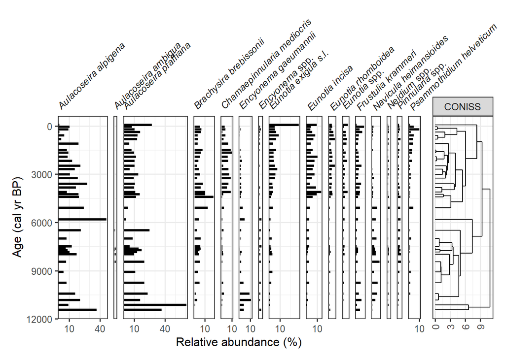

```r
patchwork::wrap_plots(
  diat_plot +
    theme(strip.background = element_blank(), strip.text.y = element_blank()),
  diat_coniss_plt +
    theme(axis.text.y.left = element_blank(), axis.ticks.y.left = element_blank()) +
    labs(y = NULL),
  nrow = 1,
  widths = c(6, 1)
)
```

## Pollen

Now we repeat the workflow with the pollen record of the site of study. First step is to extract sample-level information and filter by `ecologicalgroup` and `elementype`.

```r
pra_samp_pollen <- samples(pra_records) %>%
  dplyr::filter(ecologicalgroup %in% c("TRSH", "UPHE", "VACR")) %>%
  dplyr::filter(elementtype %in% c("pollen", "spore")) %>%
  dplyr::filter(units == "NISP")
```

Calculate pollen proportions:

```r
pra_pollen_perc <- pra_samp_pollen %>%
  dplyr::group_by(depth, age) %>%
  dplyr::mutate(pollencount = sum(value, na.rm = TRUE)) %>%
  dplyr::group_by(variablename) %>%
  dplyr::mutate(relative_abundance_percent = value / pollencount) %>%
  dplyr::arrange(desc(age))
```

Prepare the dataset and plot

```r
pollen_long <- pra_pollen_perc %>%
  dplyr::select(depth, age, variablename, relative_abundance_percent, ecologicalgroup) %>% #select the variables of interest from the sample object
  dplyr::mutate(relative_abundance_percent = as.numeric(relative_abundance_percent)) %>%
  rename(taxa=variablename) %>% #rename column variablename to taxa
  mutate(taxa = factor(taxa))

unique(pollen_long$taxa)
```

```
 [1] Abies                           Quercus
 [3] Rumex                           Ulmus
 [5] Apiaceae                        Alnus
 [7] Amaranthaceae                   Poaceae (Cerealia)
 [9] Urtica                          Bupleurum-type
[11] Plumbaginaceae                  Plantago media-type
[13] Potentilla-type                 Rubiaceae
[15] Juniperus                       Ranunculaceae
[17] Asteroideae                     Cichorioideae
[19] Polypodiophyta (without perine) Corylus
[21] Salix                           Filipendula
[23] Artemisia                       Cyperaceae
[25] Poaceae                         Betula
[27] Pinus                           Hippophaë rhamnoides
[29] Thalictrum                      Acer
```

[output cut: 31 more lines]

```r
unique(pollen_long$ecologicalgroup)
```

```
[1] "TRSH" "UPHE" "VACR"
```

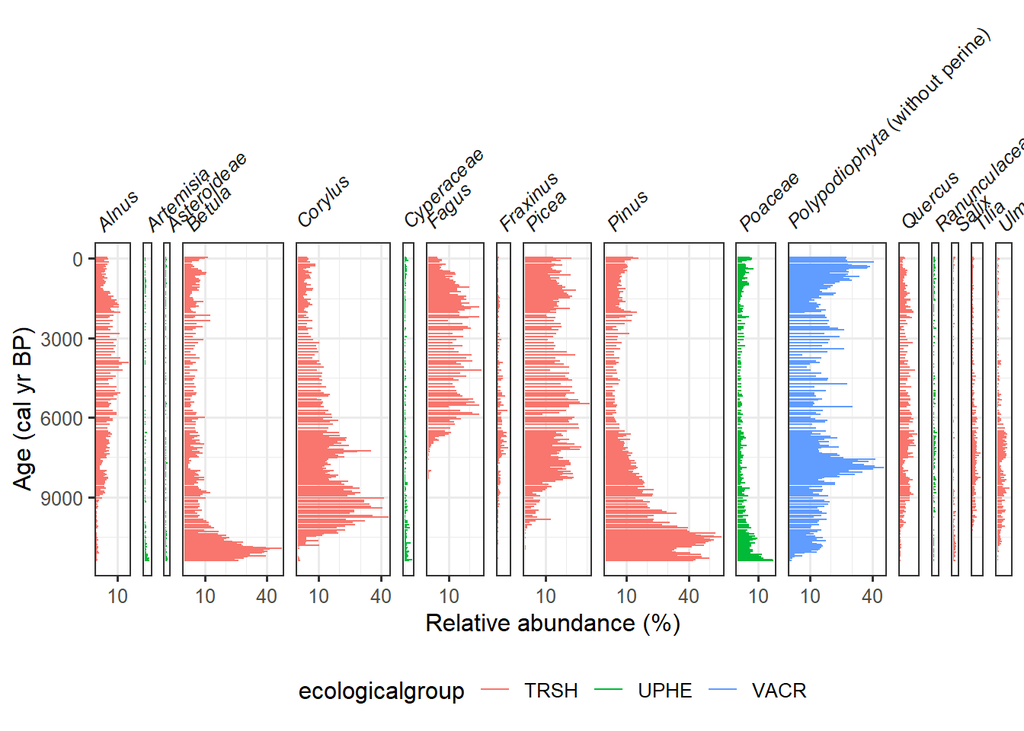

```r
# Here we select the top 20 most abundant pollen taxa
site_plot_pollen <- taxa(pra_records) %>%
  dplyr::filter(elementtype %in% c("pollen", "spore")) %>%
  dplyr::filter(units == "NISP") %>%
  dplyr::arrange(desc(samples)) %>%
  head(n = 20)

theme_set(theme_bw(base_size=12))
pollen_plot <- pollen_long %>%
  filter(taxa %in% site_plot_pollen$variablename) %>%
  ggplot(., aes(x = relative_abundance_percent*100, y = age, color=ecologicalgroup)) +
  geom_col_segsh() +
  scale_y_reverse() +
  facet_abundanceh(vars(taxa), ) +
  labs(y = "Age (cal yr BP)") +
  theme(legend.position = "bottom")
pollen_plot
```

Create a composite plot for diatoms and pollen records:

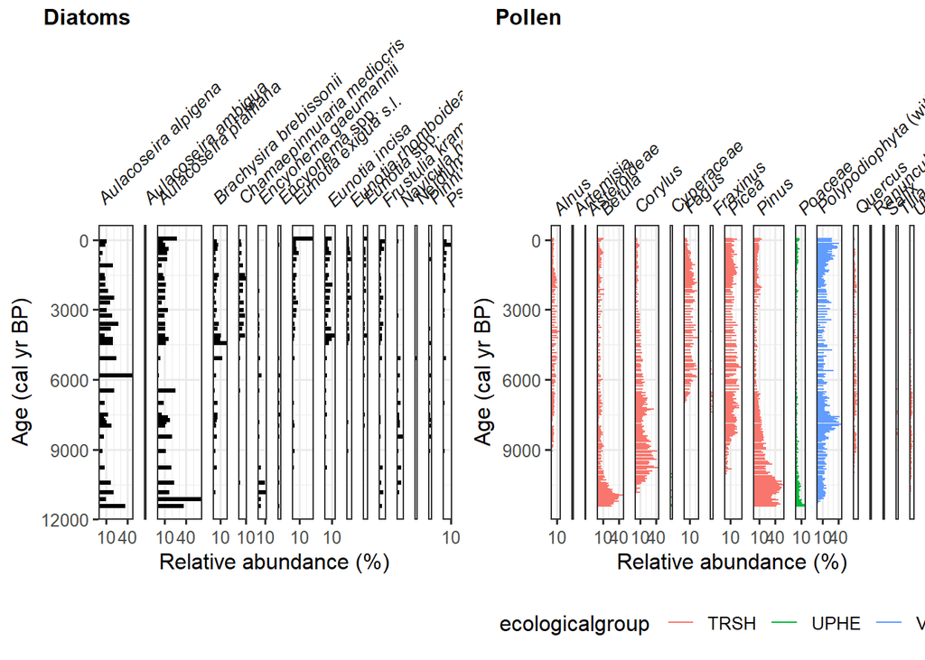

```r
plot_grid(diat_plot, pollen_plot,
                            nrow = 1,
                            labels = c("Diatoms", "Pollen"), label_size = 12,
                            rel_widths = c(0.5,0.5), align = "hv")
```

## Exercise 1

Have a look at the composite diagram and make changes to make it “printable”. For instance, the y-axis (age scale) of the pollen diagram might not be necessary, and the angle of the species label (see argument `rotate_facet_labels` in `facet_abundanceh()`)

## Exercise 2

Place the chironomid diagram next to the diatom stratigraphic plot to facilitate comparison of downcore changes in the wider aquatic assemblage.

# Option 2: `riojaPlot`

**riojaPlot** package needs a wide-format dataset, so we first take the **diatom** long-format proportions table and convert it into a wide table:

```r
pra_diat_wide <- tidyr::pivot_wider(pra_diat_perc,
                                      id_cols = c(depth, age),
                                      names_from = variablename,
                                      values_from = relative_abundance_percent,
                                      values_fill = 0)
```

We plot the diatom stratigraphic diagram:

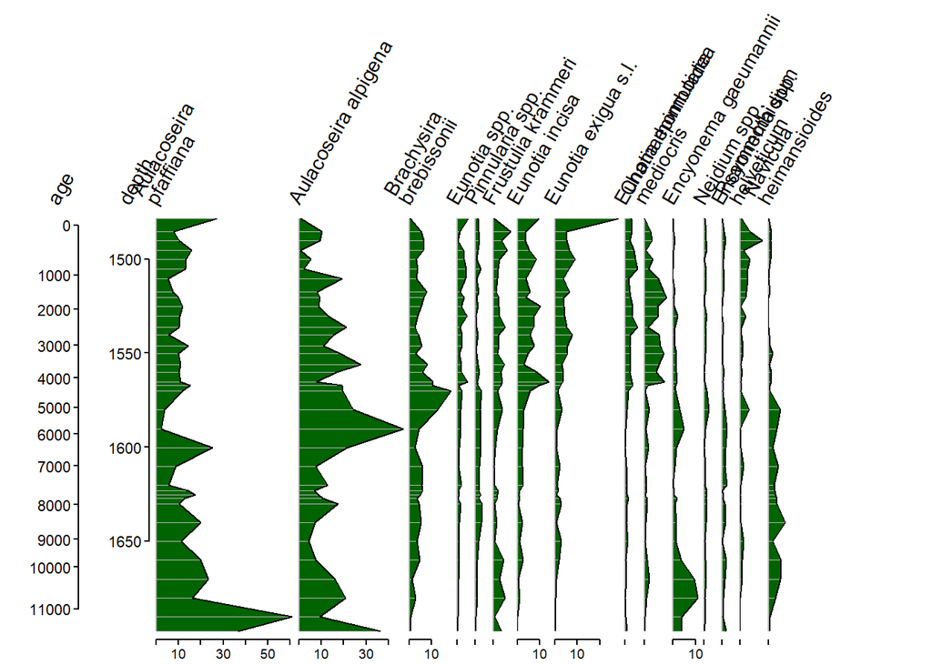

```r
riojaPlot(pra_diat_wide[,-1:-2]*100, pra_diat_wide[,1:2],
                       selVars = site_plot_diat$variablename,
                       scale.percent = TRUE,
                       sec.yvar.name="age",
                       plot.sec.axis = TRUE,
                       srt.xlabel = 60,
                       xRight = 0.85)
```

`riojaPlot` can add zonation to the stratigraphic diagram. The easiest way is with the arguments `do.clust=TRUE` to create the zonation, and `plot.clust=TRUE` to add the dendrogram.

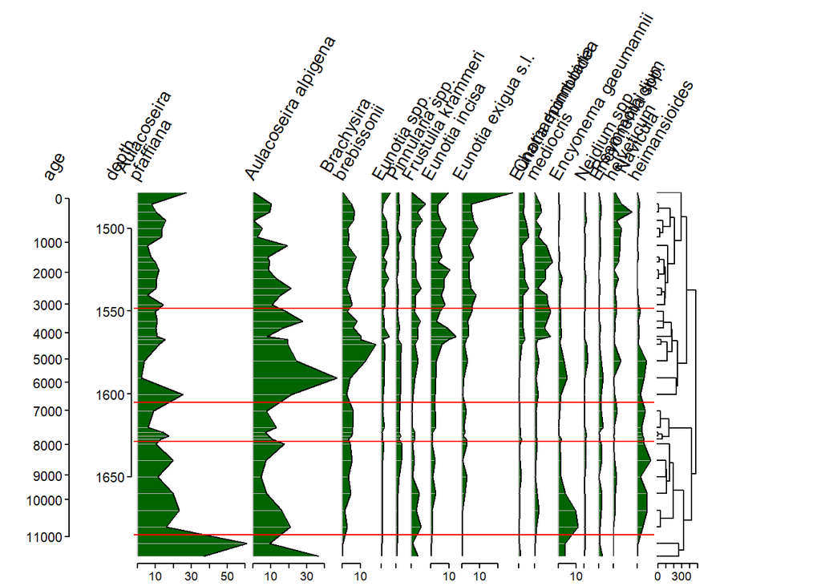

```r
riojaPlot(pra_diat_wide[,-1:-2]*100, pra_diat_wide[,1:2],
                       selVars = site_plot_diat$variablename,
                       scale.percent = TRUE,
                       sec.yvar.name="age",
                       plot.sec.axis = TRUE,
                       do.clust=TRUE,
                       plot.clust=TRUE,
                       plot.zones="auto",
                       srt.xlabel = 60,
                       xRight = 0.85)
```